# Intro to EMA

12 July 2018

## Objectives

- Review the motivating questions
- Introduce you to the structure of EMA data
- Discuss the preparation of the data
- Give an overview of the Analyses

## EMA questions

- Describing state-like variables
  - How does mood fluctuate?
- Relationships among state-like variables
  - Does state affect predict alcohol consumption?
- Relationships between state and trait-like variables
  - Does gender predict state affect?

## Cross-sectional Data

[figure not shown]

The "wide" data structure

## Longitudinal / Repeated Measures Data

[figure not shown]

## EMA data

- Necessarily contains longitudinal data
- Regularly contains cross-sectional data (baseline measures)
- Both are important to research questions

[figure not shown]

## Reading, Cleaning, and Recoding - Baseline

```r
library(readr)
library(dplyr)
library(janitor)
df1 <-  read_csv("baseline.csv") %>%
  clean_names() %>%
  mutate(id = toupper(id),    # consistently case IDs
         item1r = 11 - item1, # reverse scoring
         scale1 = (item1r + item2 + item3 + item4) / 4) # creating a summary scale

head(df1)
```

```
## # A tibble: 6 x 7
##   id       item1 item2 item3 item4 item1r scale1
##   <chr>    <int> <int> <int> <int>  <dbl>  <dbl>
## 1 AROVWF1S     6     4     5     5      5   4.75
## 2 ROSFINJF     5     6     6     6      6   6
## 3 PGO4JDC3     5     6     4     5      6   5.25
## 4 XO9OHKNA     6     5     6     6      5   5.5
## 5 QCAWSGCV     6     5     5     5      5   5
## 6 O2XBEK8S     7     5     5     6      4   5
```

## Reading, Cleaning, and Recoding - Longitudinal

```r
df2 <-  read_csv("esm.csv") %>%
  mutate(id=toupper(id)) %>%  # consistently case IDs
  group_by(id) %>%            # groups by ID (also possible to group by day here)
  arrange(id, surv_time) %>%  # sort by ID and time of survey
  mutate(ximean = mean(xi),   # obtain the group mean of IV xi (groupmean because of grouping above)
         xic = xi - ximean,   # group mean centre scores on xi
         xiclag = lag(xic))   # lag centred xi by 1 observation

head(df2)
```

```
## # A tibble: 6 x 7
## # Groups:   id [1]
##   id       surv_time              xi     y ximean     xic   xiclag
##   <chr>    <dttm>              <dbl> <dbl>  <dbl>   <dbl>    <dbl>
## 1 1WMVICLH 2018-05-01 23:06:37  6.50  30.3   4.33  2.17    NA
## 2 1WMVICLH 2018-05-02 00:46:40  6.43  37.4   4.33  2.10     2.17
## 3 1WMVICLH 2018-05-02 02:26:39  5.94  27.9   4.33  1.60     2.10
## 4 1WMVICLH 2018-05-02 04:06:39  4.31  22.3   4.33 -0.0229   1.60
## 5 1WMVICLH 2018-05-02 05:46:39  7.20  40.8   4.33  2.86    -0.0229
## 6 1WMVICLH 2018-05-02 07:26:41  5.56  19.3   4.33  1.23     2.86
```

## Combining your datasets

```r
full <-  inner_join(df2, df1, by = "id")
head(full)
```

```
## # A tibble: 6 x 13
## # Groups:   id [1]
##   id       surv_time              xi     y ximean     xic   xiclag item1
##   <chr>    <dttm>              <dbl> <dbl>  <dbl>   <dbl>    <dbl> <int>
## 1 1WMVICLH 2018-05-01 23:06:37  6.50  30.3   4.33  2.17    NA          5
## 2 1WMVICLH 2018-05-02 00:46:40  6.43  37.4   4.33  2.10     2.17       5
## 3 1WMVICLH 2018-05-02 02:26:39  5.94  27.9   4.33  1.60     2.10       5
## 4 1WMVICLH 2018-05-02 04:06:39  4.31  22.3   4.33 -0.0229   1.60       5
## 5 1WMVICLH 2018-05-02 05:46:39  7.20  40.8   4.33  2.86    -0.0229     5
## 6 1WMVICLH 2018-05-02 07:26:41  5.56  19.3   4.33  1.23     2.86       5
## # ... with 5 more variables: item2 <int>, item3 <int>, item4 <int>,
## #   item1r <dbl>, scale1 <dbl>
```

## Multi-Level Modelling (MLM)

A framework to model relationships between variables where the data are clustered (non-independent).

In terms you might be more familiar with:

- A type of analysis that can include people from within groups
- A type of analysis that can include multiple measures within people

This will be covered in week 7 of RMD

## MLMs Conceptually

Regression, but acounting for similarities in the cluster (either person or group).

Allows examination of and control for differences between the clusters.

Principally manifest as:

- Random intercepts (effect of IVs constant between groups, but different baseline of the outcome variable)
- Random effects (effect of IV varies between groups)

## MLMs Conceptually

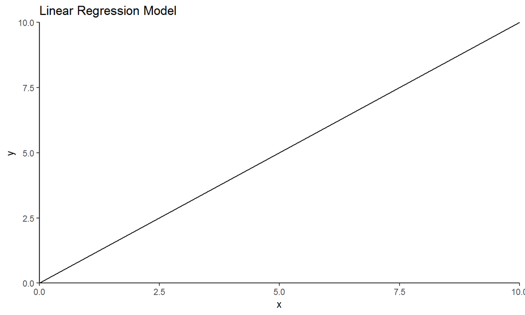

## MLMs Conceptually

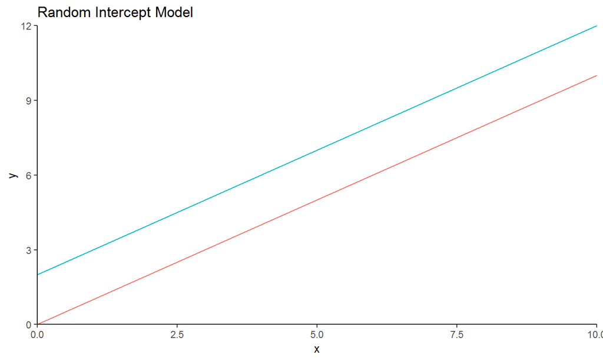

## MLMs Conceptually

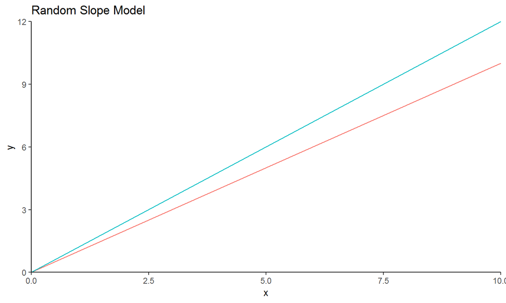

## Where is the variance?

```r
library(psychometric)

# Share of variance between subjects in dependent y
ICC2.lme(y, id, data = full)
```

```
## [1] 0.1196968
```

## Conducting a MLM

```r
library(lme4)
library(broom)
#library(lmerTest)

model1 <-  lmer(y ~ (1|id), data = full)
glance(model1)
```

```
##      sigma    logLik      AIC      BIC deviance df.residual
## 1 12.62391 -3560.374 7126.747 7141.155 7120.981         897
```

## Conducting a MLM

```r
tidy(model1)
```

```
##                      term   estimate std.error statistic    group
## 1             (Intercept) 19.3212204  0.448495  43.08012    fixed
## 2       sd_(Intercept).id  0.8498975        NA        NA       id
## 3 sd_Observation.Residual 12.6239147        NA        NA Residual
```

## Conducting a MLM

```r
model2 <-  lmer(y ~ xic + scale1 + (1|id), data = full)
glance(model2)
```

```
##      sigma    logLik      AIC     BIC deviance df.residual
## 1 3.725155 -2498.909 5007.818 5031.83 4995.721         895
```

```r
anova(model1, model2)
```

```
## Data: full
## Models:
## model1: y ~ (1 | id)
## model2: y ~ xic + scale1 + (1 | id)
##        Df    AIC    BIC  logLik deviance  Chisq Chi Df Pr(>Chisq)
## model1  3 7127.0 7141.4 -3560.5   7121.0
## model2  5 5005.7 5029.7 -2497.8   4995.7 2125.3      2  < 2.2e-16 ***
## ---
## Signif. codes:  0 '***' 0.001 '**' 0.01 '*' 0.05 '.' 0.1 ' ' 1
```

## Conducting a MLM

```r
summary(model2)
```

```
## Linear mixed model fit by REML ['lmerMod']
## Formula: y ~ xic + scale1 + (1 | id)
##    Data: full
##
## REML criterion at convergence: 4997.8
##
## Scaled residuals:
##     Min      1Q  Median      3Q     Max
## -3.0252 -0.6597 -0.0464  0.6726  3.2106
##
## Random effects:
##  Groups   Name        Variance Std.Dev.
##  id       (Intercept)  5.65    2.377
##  Residual             13.88    3.725
## Number of obs: 900, groups:  id, 30
##
## Fixed effects:
##             Estimate Std. Error t value
## (Intercept) 22.83123    4.45233   5.128
## xic          5.58477    0.05847  95.510
## scale1      -0.66964    0.84503  -0.792
##
## Correlation of Fixed Effects:
##        (Intr) xic
## xic     0.000
## scale1 -0.995  0.000
```